# Variable and Modality Clustering Package

Eugénie Barlet, Modou Mboup, Axel Cano

2025-11-26

# 1 Introduction

This vignette provides a comprehensive guide to the **VarClustering** package, which implements three complementary clustering approaches for variable reduction and pattern discovery:

1. **HClustVar** - Hierarchical clustering of variables (quantitative, qualitative, or mixed)
2. **KmeansVariables** - K-means clustering of quantitative variables using PCA centroids
3. **ModCluster** - Modality-based clustering using Dice distance for categorical data

## 1.1 Package Overview

| Algorithm | Data Type | Distance/Similarity | Output |
| --- | --- | --- | --- |
| HClustVar | Quantitative / Qualitative / Mixed | R, R², Cramer’s V | Variable clusters |
| KmeansVariables | Quantitative only | R, R² | Variable clusters |
| ModCluster | Categorical only | Dice distance | Modality clusters |

## 1.2 Loading the Package

```r
library(VarClustering)
```

## 1.3 Datasets

# 2 Part 1: Hierarchical Variable Clustering (HClustVar)

## 2.1 1.1 Introduction

The `HClustVar` class implements hierarchical clustering of variables using Agglomerative Hierarchical Clustering (AHC). It groups variables based on their similarity, supporting:

- **Quantitative variables**: Correlation (r) or squared correlation (r²)
- **Qualitative variables**: Cramer’s V
- **Mixed variables**: Discretization + Cramer’s V

### 2.1.1 Key Features

- Automatic variable type detection
- Multiple distance metrics and linkage methods
- Comprehensive diagnostics (silhouette, MDS, dendrograms)
- Prediction on illustrative variables

## 2.2 1.2 Example 1: Quantitative Variables (Automotive Data)

### 2.2.1 Loading and Exploring

```r
# Load the autos dataset
data(autos)

# Display structure
str(autos)
```

```
## 'data.frame':    33 obs. of  12 variables:
##  $ Modele   : Factor w/ 33 levels "ALFA 156","AUDIA3",..: 10 15 25 9 11 8 24 20 17 23 ...
##  $ puissance: num  210 165 136 138 100 61 180 113 165 75 ...
##  $ cylindree: num  2496 1998 1997 1997 1461 ...
##  $ vitesse  : num  230 218 212 207 185 158 225 188 225 165 ...
##  $ longueur : num  475 458 468 426 382 367 435 380 436 374 ...
##  $ largeur  : num  178 178 182 178 164 166 176 170 178 169 ...
##  $ hauteur  : num  148 143 145 146 142 147 143 159 141 161 ...
##  $ poids    : num  1589 1320 1415 1381 980 ...
##  $ CO2      : num  238 196 194 142 113 141 210 163 191 153 ...
##  $ prix     : num  33000 25350 23400 23400 17600 ...
##  $ origine  : Factor w/ 3 levels "Autres","Europe",..: 3 3 3 3 3 3 3 3 3 3 ...
##  $ carburant: Factor w/ 2 levels "Diesel","Essence": 2 2 2 1 1 2 2 2 2 2 ...
```

```r
# Summary
summary(autos)
```

```
##       Modele     puissance       cylindree       vitesse         longueur
##  ALFA 156: 1   Min.   : 54.0   Min.   : 998   Min.   :150.0   Min.   :344.0
##  AUDIA3  : 1   1st Qu.:100.0   1st Qu.:1461   1st Qu.:179.0   1st Qu.:384.0
##  AUDIA8  : 1   Median :145.0   Median :1995   Median :207.0   Median :436.0
##  AVENSIS : 1   Mean   :150.5   Mean   :2104   Mean   :202.8   Mean   :432.3
##  BMW X5  : 1   3rd Qu.:204.0   3rd Qu.:2429   3rd Qu.:225.0   3rd Qu.:471.0
##  BMW530  : 1   Max.   :340.0   Max.   :5654   Max.   :250.0   Max.   :506.0
##  (Other) :27
##     largeur         hauteur          poids           CO2             prix
##  Min.   :159.0   Min.   :134.0   Min.   : 840   Min.   :113.0   Min.   : 8070
##  1st Qu.:170.0   1st Qu.:143.0   1st Qu.:1181   1st Qu.:143.0   1st Qu.:17600
##  Median :177.0   Median :146.0   Median :1381   Median :183.0   Median :25350
##  Mean   :176.5   Mean   :148.6   Mean   :1364   Mean   :185.7   Mean   :27938
##  3rd Qu.:182.0   3rd Qu.:150.0   3rd Qu.:1495   3rd Qu.:223.0   3rd Qu.:34000
##  Max.   :203.0   Max.   :172.0   Max.   :2095   Max.   :291.0   Max.   :78340
##
##    origine     carburant
##  Autres: 5   Diesel :13
##  Europe:15   Essence:20
##  France:13
##
##
##
##
```

### 2.2.2 Splitting Data

```r
# Split into active and illustrative variables
autos_train <- autos[, 2:9]
autos_test <- autos[, 10:12]
```

### 2.2.3 Fitting the Model

```r
# Initialize HClustVar
hc_auto <- HClustVar$new(
  vartype = "quant",
  dist.metric = "rsquare",
  cah.method = "ward.D2"
)

# Fit the model
hc_auto$fit(autos_train)

# Print summary
print(hc_auto)
```

```
##
## ══════════════════════════════════════════════════════
##             Hierarchical Variable Clustering
## ══════════════════════════════════════════════════════
##
## Status: ✓ FITTED
##
## Data:          8 variables × 33 observations
## Variable type: quant
## CAH method:    ward.D2
## Distance:      rsquare
##
## Clusters:      Tree not cut (use $cut_tree())
##
## ══════════════════════════════════════════════════════
## Use $summary() for detailed information and cluster analysis
## Use $plot_dendrogram() to visualize the tree
## Use $plot_agg_levels() to visualize the inertia of clusters
## Use $plot_silhouette() to visualize the silhouette plot of clusters
## Use $mds_projection() to compute multidimensional scaling
```

### 2.2.4 Visualizing the Dendrogram

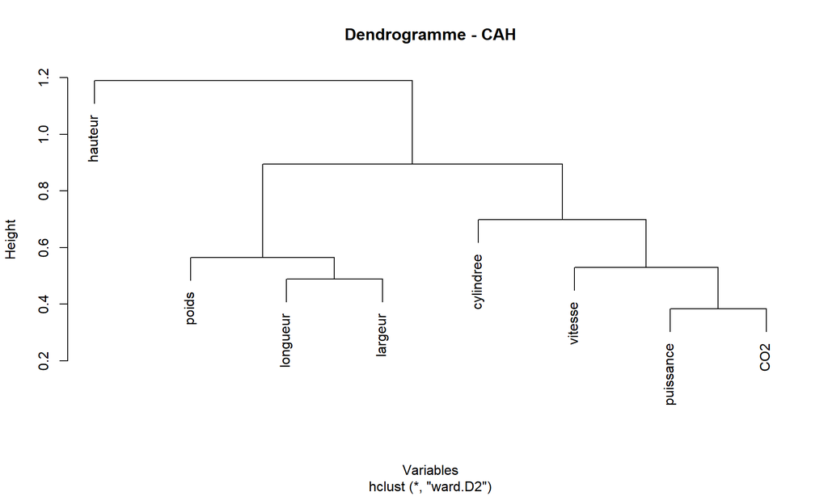

```r
hc_auto$plot_dendrogram()
```

### 2.2.5 Determining Optimal K

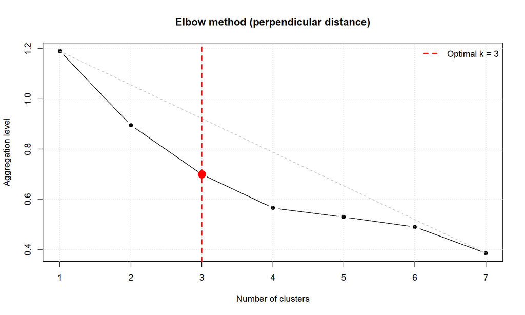

```r
hc_auto$plot_agg_levels()
```

### 2.2.6 Cutting the Tree

```r
# Cut into 3 clusters
hc_auto$cut_tree(k = 3)
```

```
## puissance cylindree   vitesse  longueur   largeur   hauteur     poids       CO2
##         1         1         1         2         2         3         2         1
```

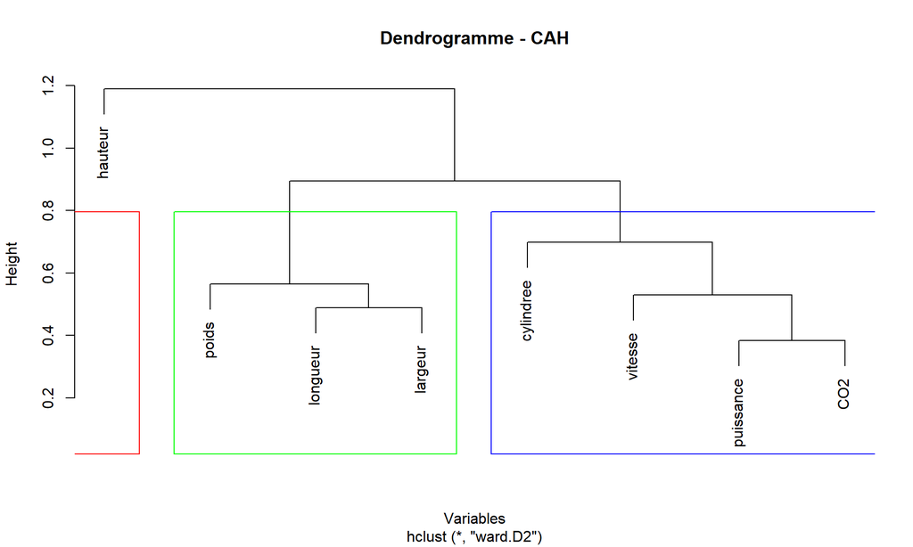

```r
# Visualize with cluster colors
hc_auto$plot_dendrogram(k = 3)
```

### 2.2.7 Quality Assessment

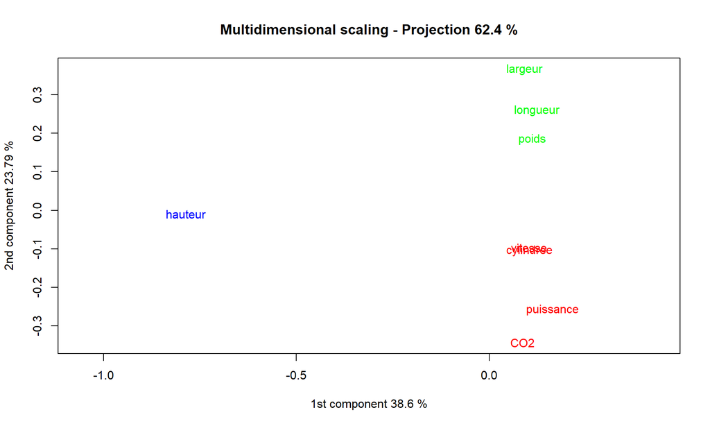

```r
# MDS projection
hc_auto$mds_projection()
```

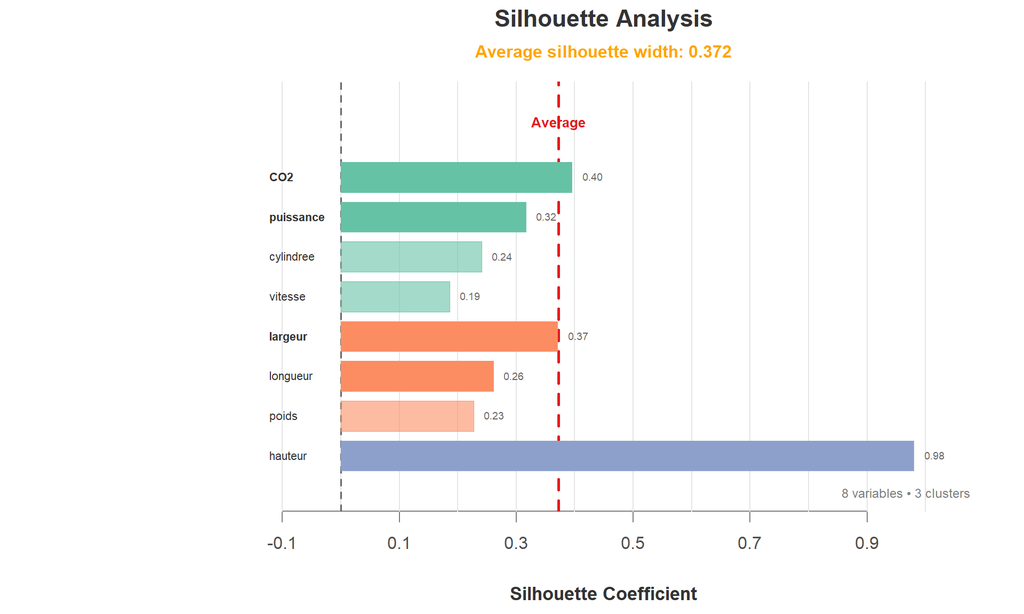

```r
# Silhouette plot
hc_auto$plot_silhouette()
```

### 2.2.8 Analyzing Results

```r
results <- hc_auto$summary()

# Quality metrics
cat("Average silhouette:", results$avg_silhouette, "\n")
```

```
## Average silhouette: 0.375
```

```r
cat("Variance explained:", results$total_var_explained, "\n")
```

```
## Variance explained: 89.88
```

```r
# Cluster summary
results$clust_summary
```

```
##    cluster n_members var_explained prop_explained avg_silhouette
## C1       1         4          3.49           0.87          0.288
## C2       2         3          2.70           0.90          0.291
## C3       3         1          1.00           1.00          0.978
```

```r
# Cluster members
results$clust_members
```

```
##           cluster own_cluster_R2 next_closest_R2 1 - R2_ratio silhouette
## puissance       1           0.98            0.67         0.06      0.321
## vitesse         1           0.86            0.70         0.47      0.194
## CO2             1           0.86            0.52         0.29      0.396
## cylindree       1           0.79            0.60         0.52      0.239
## longueur        2           0.92            0.68         0.25      0.267
## largeur         2           0.89            0.56         0.25      0.374
## poids           2           0.88            0.68         0.38      0.230
## hauteur         3           1.00            0.02         0.00      0.978
```

```r
# Centroid correlations
results$centroids_correlations
```

```
##   cluster A cluster B correlation squared_correlations
## 1        C1        C2       0.841                0.707
## 2        C1        C3       0.148                0.022
## 3        C2        C3       0.005                0.000
```

### 2.2.9 Prediction on Illustrative Variables

```r
# Predict cluster for illustrative variables
prediction <- hc_auto$predict(autos_test)

# Labels
prediction$labels
```

```
##      prix   origine carburant
##         1         1         3
```

```r
# Proximities to all clusters
prediction$proximities
```

```
##    Variable  Cluster_1   Cluster_2    Cluster_3
## 1      prix 0.80188294 0.782477741 0.0004618081
## 2   origine 0.05432635 0.019945784 0.0254374633
## 3 carburant 0.04662798 0.004075258 0.0798669015
```

## 2.3 1.3 Example 2: Qualitative Variables (Canines Dataset)

```r
# Load canines dataset
data(canines)

# Display
summary(canines)
```

```
##          Chien         Taille       Poids       Velocite    Intelligence
##  Basset     : 1   Taille- : 7   Poids- : 8   Veloc- :10   Intell- : 8
##  Beauceron  : 1   Taille+ : 5   Poids+ :14   Veloc+ : 8   Intell+ :13
##  Berger All : 1   Taille++:15   Poids++: 5   Veloc++: 9   Intell++: 6
##  Boxer      : 1
##  Bull-Dog   : 1
##  Bull-Mastif: 1
##  (Other)    :21
##   Affection   Agressivite      Fonction
##  Affec-:13   Agress-:14   chasse   : 9
##  Affec+:14   Agress+:13   compagnie:10
##                           utilite  : 8
##
##
##
##
```

```r
head(canines)
```

```
## # A tibble: 6 × 8
##   Chien       Taille  Poids Velocite Intelligence Affection Agressivite Fonction
##   <fct>       <fct>   <fct> <fct>    <fct>        <fct>     <fct>       <fct>
## 1 Beauceron   Taille… Poid… Veloc++  Intell+      Affec+    Agress+     utilite
## 2 Basset      Taille- Poid… Veloc-   Intell-      Affec-    Agress+     chasse
## 3 Berger All  Taille… Poid… Veloc++  Intell++     Affec+    Agress+     utilite
## 4 Boxer       Taille+ Poid… Veloc+   Intell+      Affec+    Agress+     compagn…
## 5 Bull-Dog    Taille- Poid… Veloc-   Intell+      Affec+    Agress-     compagn…
## 6 Bull-Mastif Taille… Poid… Veloc-   Intell++     Affec-    Agress+     utilite
```

### 2.3.1 Full Pipeline

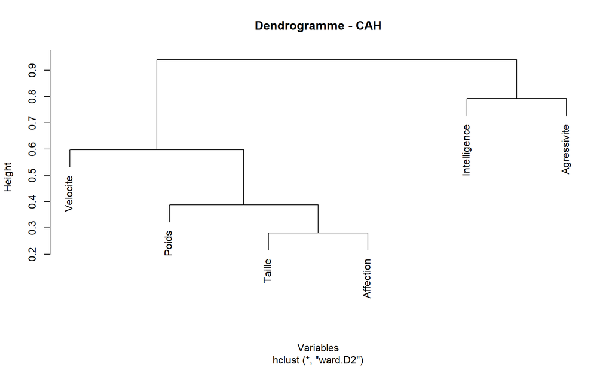

```r
# Select active variables
canines_actives <- canines[, 2:7]

# Initialize for qualitative variables
hc_canines <- HClustVar$new(
  vartype = "qual",
  cah.method = "ward.D2"
)

# Fit
hc_canines$fit(canines_actives)

# Dendrogram
hc_canines$plot_dendrogram()
```

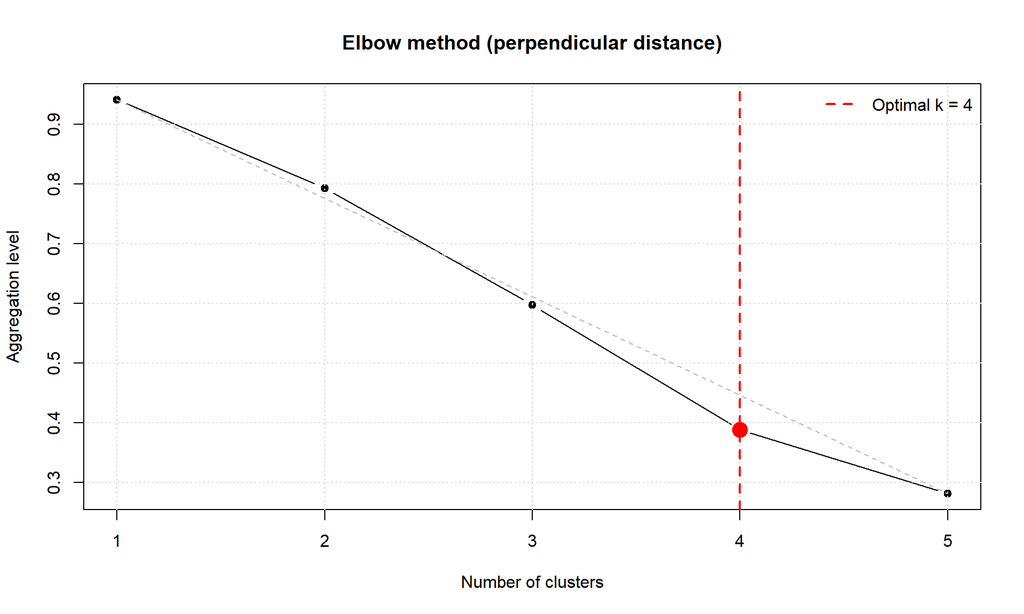

```r
# Aggregation levels
hc_canines$plot_agg_levels()
```

```r
# Cut and analyze
hc_canines$cut_tree(4)
```

```
##       Taille        Poids     Velocite Intelligence    Affection  Agressivite
##            1            1            2            3            1            4
```

```r
canines_result <- hc_canines$summary()

# Results
canines_result$clust_summary
```

```
##    cluster n_members var_explained prop_explained avg_silhouette
## C1       1         3           0.8           0.27          0.749
## C2       2         1           1.0           1.00          0.792
## C3       3         1           1.0           1.00          0.944
## C4       4         1           1.0           1.00          0.920
```

```r
canines_result$clust_members
```

```
##              cluster own_cluster_R2 next_closest_R2 1 - R2_ratio silhouette
## Taille             1           0.89            0.41         0.19      0.544
## Poids              1           0.83            0.09         0.19      0.886
## Affection          1           0.67            0.12         0.37      0.818
## Velocite           2           1.00            0.21         0.00      0.792
## Intelligence       3           1.00            0.06         0.00      0.944
## Agressivite        4           1.00            0.08         0.00      0.920
```

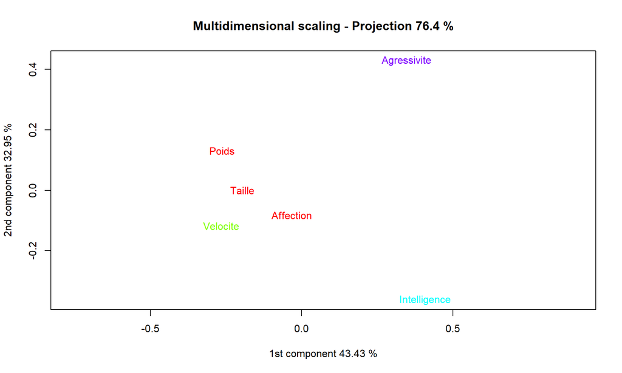

```r
# MDS visualization
hc_canines$mds_projection()
```

# 3 Part 2: K-means Variable Clustering (KmeansVariables)

## 3.1 2.1 Introduction

The `KmeansVariables` class implements K-means clustering of variables using PCA to compute cluster centroids. It groups variables by maximizing their correlation with these centroids.

### 3.1.1 Algorithm Overview

1. **Initialization**: Randomly assign variables to K clusters
2. **Centroid Calculation**: Compute first principal component (PCA) as centroid
3. **Distance Calculation**: Compute distance based on correlation with centroids
4. **Reallocation**: Reassign variables to nearest centroid
5. **Iteration**: Repeat until convergence

### 3.1.2 Distance Metrics

- **R² (r_squared)**: Groups variables with high absolute correlation
  $$d(x_j, c_k) = \sqrt{1
  - r^2(x_j, c_k)}$$
- **Signed r (r_signed)**: Groups only positively correlated variables
  $$d(x_j, c_k) = 1 -
  r(x_j, c_k)$$

### 3.1.3 Key Features

- Multiple random initializations
- Automatic K selection (elbow, silhouette, Calinski-Harabasz)
- Comprehensive diagnostics
- Prediction on illustrative variables

### 3.2.1 Loading and Exploring

```r
# Load autos dataset
data(autos)

# Display structure
cat("Dimensions:", dim(autos), "\n")
```

```
## Dimensions: 33 12
```

```r
cat("Variables:", paste(head(names(autos), 10), collapse = ", "), "...\n")
```

```
## Variables: Modele, puissance, cylindree, vitesse, longueur, largeur, hauteur, poids, CO2, prix ...
```

```r
# Summary
summary(autos[, 1:6])
```

```
##       Modele     puissance       cylindree       vitesse         longueur
##  ALFA 156: 1   Min.   : 54.0   Min.   : 998   Min.   :150.0   Min.   :344.0
##  AUDIA3  : 1   1st Qu.:100.0   1st Qu.:1461   1st Qu.:179.0   1st Qu.:384.0
##  AUDIA8  : 1   Median :145.0   Median :1995   Median :207.0   Median :436.0
##  AVENSIS : 1   Mean   :150.5   Mean   :2104   Mean   :202.8   Mean   :432.3
##  BMW X5  : 1   3rd Qu.:204.0   3rd Qu.:2429   3rd Qu.:225.0   3rd Qu.:471.0
##  BMW530  : 1   Max.   :340.0   Max.   :5654   Max.   :250.0   Max.   :506.0
##  (Other) :27
##     largeur
##  Min.   :159.0
##  1st Qu.:170.0
##  Median :177.0
##  Mean   :176.5
##  3rd Qu.:182.0
##  Max.   :203.0
##
```

### 3.2.2 Fitting the Model

```r
# Initialize KmeansVariables
km <- KmeansVariables$new(
  n_clusters = 5,
  n_init = 10,
  distance_metric = "r_squared",
  random_state = 42
)

# Fit
km$fit(autos)

# Print
print(km)
```

```
## K-means Variable Clustering
## ===========================
##
## Number of clusters: 5
## Number of variables: 9
## Iterations: 2
## Total inertia: 8.39
##
## Cluster sizes:
##
## 1 2 3 4 5
## 4 1 1 2 1
```

### 3.2.3 Accessing Results

```r
# Cluster assignments
head(km$labels, 10)
```

```
## [1] 1 1 5 4 4 2 3 1 1
```

```r
# Cluster sizes
km$cluster_sizes
```

```
## Cluster1 Cluster2 Cluster3 Cluster4 Cluster5
##        4        1        1        2        1
```

```r
# Total inertia
cat("Total inertia:", round(km$inertia, 4), "\n")
```

```
## Total inertia: 8.39
```

## 3.3 2.3 Visualizations

### 3.3.1 Elbow Plot

Elbow plot require a lot of computation time because of all the iterations needed to compute the graph. this method should be avoided on dataset containing a lot of columns.

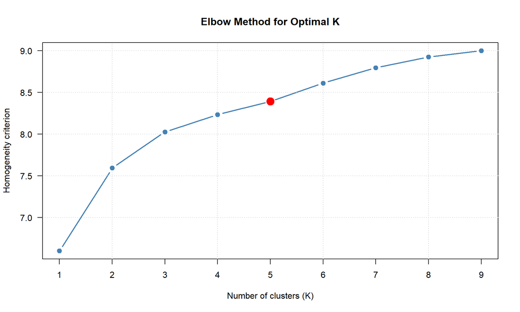

```r
km$plot_elbow()
```

### 3.3.2 Variable Projection

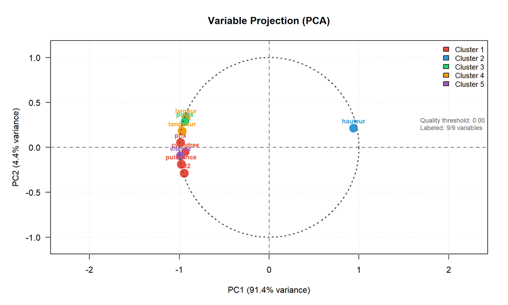

```r
km$plot_projection(show_labels = TRUE)
```

### 3.3.3 Top Contributing Variables

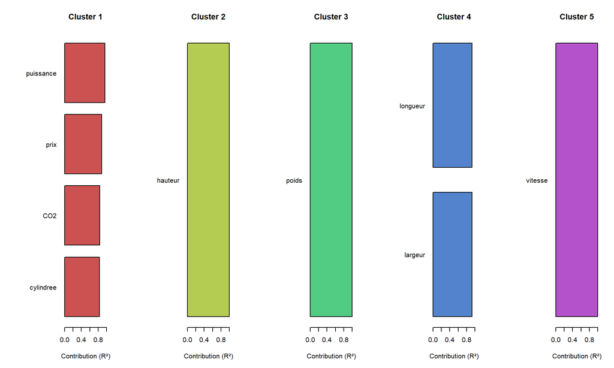

```r
km$plot_contributions(top_n = 5)
```

## 3.4 2.4 Analyzing Results

### 3.4.1 Summary

```r
results_km <- km$summary(print_summary = TRUE)
```

```
## K-means Variable Clustering
## ===========================
##
## Number of clusters: 5
## Number of variables: 9
## Total variance explained: 93.22%
## Average silhouette: 0.6195
##
## Cluster Summary:
##          cluster n_members variation_explained proportion_explained
## Cluster1       1         4              3.5177               0.8794
## Cluster2       2         1              1.0000               1.0000
## Cluster3       3         1              1.0000               1.0000
## Cluster4       4         2              1.8722               0.9361
## Cluster5       5         1              1.0000               1.0000
```

### 3.4.2 Cluster Summary

```r
results_km$clust_summary
```

```
##          cluster n_members variation_explained proportion_explained
## Cluster1       1         4              3.5177               0.8794
## Cluster2       2         1              1.0000               1.0000
## Cluster3       3         1              1.0000               1.0000
## Cluster4       4         2              1.8722               0.9361
## Cluster5       5         1              1.0000               1.0000
```

### 3.4.3 Variable Assignments

```r
head(results_km$clust_members, 10)
```

```
##           cluster own_cluster_R2 next_closest_R2 1 - R2_ratio
## puissance       1           0.96            0.83         0.23
## prix            1           0.88            0.74         0.44
## CO2             1           0.84            0.67         0.49
## cylindree       1           0.83            0.61         0.43
## hauteur         2           1.00            0.08         0.00
## poids           3           1.00            0.75         0.00
## longueur        4           0.94            0.74         0.25
## largeur         4           0.94            0.66         0.19
## vitesse         5           1.00            0.77         0.00
```

### 3.4.4 Centroid Correlations

```r
round(results_km$centroids_correlations, 3)
```

```
##           VCHca_1_1 VCHca_1_2 VCHca_1_3 VCHca_1_4 VCHca_1_5
## VCHca_1_1     1.000    -0.078     0.845     0.817     0.880
## VCHca_1_2    -0.078     1.000     0.194    -0.106    -0.278
## VCHca_1_3     0.845     0.194     1.000     0.865     0.771
## VCHca_1_4     0.817    -0.106     0.865     1.000     0.828
## VCHca_1_5     0.880    -0.278     0.771     0.828     1.000
```

# 4 Part 3: Modality Clustering (ModCluster)

## 4.1 3.1 Introduction

The `ModCluster` class implements hierarchical clustering of modalities (categories) using the Dice distance coefficient. It clusters the categories of categorical variables rather than the variables themselves.

### 4.1.1 Algorithm Overview

1. **Complete Disjunctive Table**: Convert categorical data to binary indicators
2. **Dice Distance**: Compute dissimilarity between all pairs of modalities
3. **Hierarchical Clustering**: Apply agglomerative clustering
4. **MCA Visualization**: Project modalities in reduced dimensional space

### 4.1.2 Dice Distance Formula

$$D(j, j') = \frac{1}{2}
\sum_{i=1}^{n} (x_{ij} - x_{ij'})^2$$

### 4.1.3 Key Features

- Specialized for categorical data
- Multiple linkage methods
- MCA integration for visualization
- Prediction for new observations

## 4.2 3.2 Example: Congressional Voting Dataset

### 4.2.1 Loading and Exploring

```r
# Load vote dataset
data(vote)

# Display
cat("Dimensions:", dim(vote), "\n")
```

```
## Dimensions: 435 7
```

```r
cat("Variables:", paste(names(vote), collapse = ", "), "\n")
```

```
## Variables: affiliation, budget, physician, salvador, nicaraguan, missile, education
```

```r
# Summary
summary(vote)
```

```
##      affiliation      budget      physician      salvador     nicaraguan
##  democrat  :267   n      :171   n      :247   n      :208   n      :178
##  republican:168   neither: 11   neither: 11   neither: 15   neither: 15
##                   y      :253   y      :177   y      :212   y      :242
##     missile      education
##  n      :206   n      :233
##  neither: 22   neither: 31
##  y      :207   y      :171
```

### 4.2.2 Splitting Data

```r
# Split for prediction example
set.seed(42)
train_idx <- sample(nrow(vote), size = round(0.8 * nrow(vote)))
vote_train <- vote[train_idx, ]
vote_test <- vote[-train_idx, ]

cat("Training:", nrow(vote_train), "observations\n")
```

```
## Training: 348 observations
```

```r
cat("Test:", nrow(vote_test), "observations\n")
```

```
## Test: 87 observations
```

### 4.2.3 Fitting the Model

```r
# Initialize ModCluster
mc <- ModCluster$new(
  method = "hclust",
  n_dimensions = 2,
  hclust_method = "average"
)

# Fit
mc$fit(vote_train)

# Print
print(mc)
```

```
## Method: Hierarchical Clustering (average)
## Modalities: 20
## Clusters: Not yet specified (use cut_tree)
```

## 4.3 3.3 Determining Optimal K

### 4.3.1 Aggregation Heights

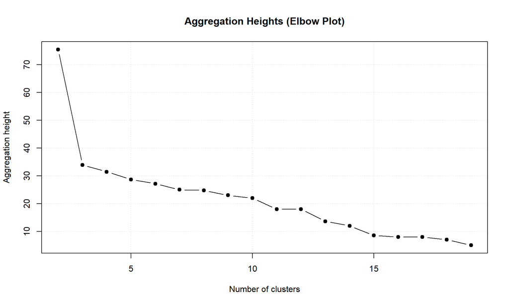

```r
mc$plot_heights()
```

### 4.3.2 Cutting the Tree

```r
mc$cut_tree(3)
print(mc)
```

```
## Method: Hierarchical Clustering (average)
## Modalities: 20
## Clusters: 3
##
## Cluster sizes:
##
## 1 2 3
## 7 7 6
```

## 4.4 3.4 Visualizations

### 4.4.1 Dendrogram

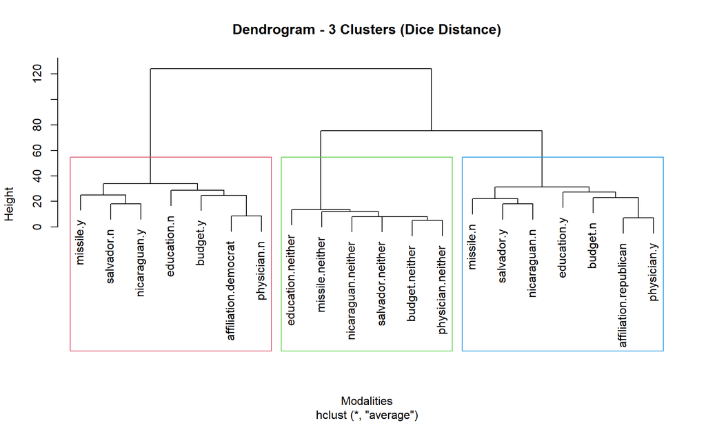

```r
mc$plot_dendrogram()
```

### 4.4.2 MCA Projection

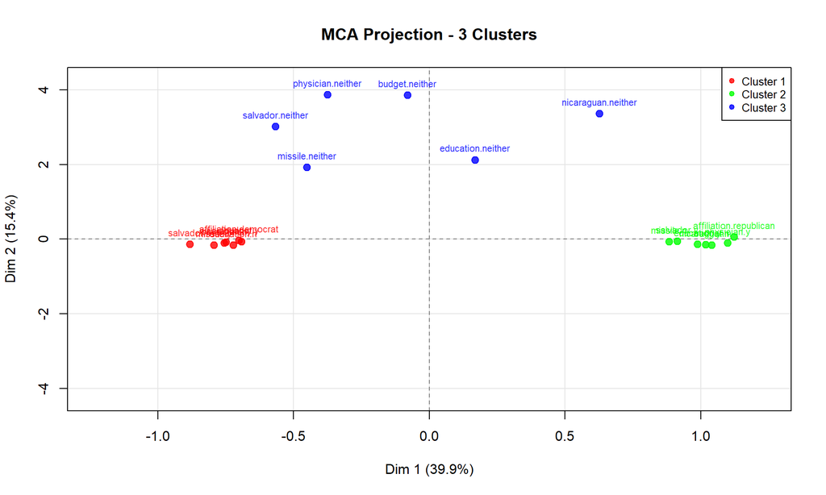

```r
mc$plot_mca()
```

## 4.5 3.5 Analyzing Results

### 4.5.1 Summary

```r
summary(mc)
```

```
## $avg_silhouette
## [1] 0.7631
##
## $total_var_explained
## [1] 0.9376
##
## $clust_summary
##   Cluster n_members within_var avg_silhouette
## 1       1         7    2776.07          73.64
## 2       2         7    2385.57          68.81
## 3       3         6     309.17          88.17
##
## $modality_quality
##                  Modality Cluster own_cluster_distance next_closest_distance
## 1    affiliation.democrat       1                22.71                105.50
```

[output cut: 69 more lines]

# 5 Method Comparison

## 5.1 Overview

| Feature | HClustVar | KmeansVariables | ModCluster |
| --- | --- | --- | --- |
| **Clusters** | Variables | Variables | Modalities |
| **Data types** | Quant / Qual / Mixed | Quantitative only | Categorical only |
| **Algorithm** | Hierarchical (AHC) | Iterative reallocation | Hierarchical (AHC) |
| **Distance** | R, R², Cramer’s V | R, R² | Dice coefficient |
| **Visualization** | Dendrogram, MDS | PCA projection | Dendrogram, MCA |
| **Output** | Variable groups | Variable groups | Category groups |

## 5.2 When to Use Each Method

### 5.2.1 HClustVar

- **Best for**: Mixed data, exploring hierarchical structure
- **Pros**: Flexible, handles any variable type, dendrogram visualization
- **Cons**: Must choose where to cut tree

### 5.2.2 KmeansVariables

- **Best for**: Large quantitative datasets, when K is known
- **Pros**: Fast, multiple initializations, automatic K selection
- **Cons**: Quantitative only, sensitive to initialization

### 5.2.3 ModCluster

- **Best for**: Understanding categorical data patterns
- **Pros**: Specialized for categories, MCA visualization
- **Cons**: Categorical only, many modalities can be hard to interpret

# 6 Practical Recommendations

## 6.1 1. Data Preparation

- **HClustVar**: Convert characters to factors for qualitative
- **KmeansVariables**: Ensure all numeric, remove constant variables
- **ModCluster**: All variables must be factors

## 6.2 2. Choosing K

- Use elbow/aggregation plots
- Check silhouette scores
- Consider interpretability
- Try multiple values

## 6.3 3. Quality Assessment

- **Silhouette > 0.5**: Good clustering
- **Silhouette 0.25-0.5**: Reasonable
- **Silhouette < 0.25**: Consider different K or method

## 6.4 4. Interpretation

- Examine cluster composition
- Look for thematic patterns
- Use visualizations
- Validate with domain knowledge

# 7 Conclusion

This vignette demonstrated the three clustering methods in the VarClustering package:

1. **HClustVar**: Hierarchical variable clustering for quantitative, qualitative, or mixed data
2. **KmeansVariables**: K-means variable clustering with PCA centroids for quantitative data
3. **ModCluster**: Modality clustering with Dice distance for categorical data

Each method provides: - Cluster quality assessment (silhouette, variance explained) - Visualization tools - Prediction capabilities

Choose the appropriate method based on your data type and analysis goals.

# 8 References

- Rakotomalala, R. (2022). Clustering de variables. Support de cours, Université Lyon 2. https://eric.univ-lyon2.fr/ricco/cours/slides/classification_de_variables.pdf
- Rakotomalala, R. (2008). Classification de variables. Tutoriels Tanagra pour le Data Mining. http://tutoriels-data-mining.blogspot.com/2008/03/classification-de-variables.html
- Vigneau, E., & Qannari, E. M. (2003). Clustering of variables around latent components. Communications in Statistics-Simulation and Computation, 32(4), 1131-1150. https://doi.org/10.1081/SAC-120023882
- Chavent, M., Kuentz-Simonet, V., Labenne, A., & Saracco, J. (2012). ClustOfVar: An R package for the clustering of variables. Journal of Statistical Software, 50(13), 1-16. https://doi.org/10.18637/jss.v050.i13
- Ward, J. H. (1963). Hierarchical grouping to optimize an objective function. Journal of the American Statistical Association, 58(301), 236-244.
- Lebart, L., Morineau, A., & Piron, M. (2006). Statistique exploratoire multidimensionnelle : Visualisation et inférences en fouille de données (4e éd.). Dunod.